# Logistic Regression

Andreas Blombach & Philipp Heinrich

July 19, 2022

```r
rm(list = ls())
library(tidyverse)
```

## Logistic Regression

- so far: metric response
- what if response is categorical?
- data set: utterances with or without gesture
- goal: predict whether there is a gesture accompanying the utterance

```r
gestures <- read_tsv("../data/gestures.tsv", col_types = "fffcdl")
glimpse(gestures)
```

```
## Rows: 629
## Columns: 6
## $ gesture   <fct> 0, 1, 1, 1, 0, 1, 1, 0, 1, 0, 0, 0, 0, 1, 0, 0, 0, 0, 1, 0, …
## $ verb      <fct> lob, lob, lob, lob, lob, lob, lob, lob, lob, lob, lob, lob, …
## $ metaphor  <fct> metaphorical, metaphorical, metaphorical, literal, literal, …
## $ surface   <chr> "lobbed", "lob", "lob", "lobbed", "lobbing", "lobbing", "lob…
## $ agitation <dbl> -1.574532163, -0.009241249, 4.052165766, 0.957480751, -8.950…
## $ formality <lgl> TRUE, TRUE, TRUE, TRUE, FALSE, TRUE, TRUE, TRUE, TRUE, FALSE…
```

- verb: which verb was used?
- metaphor: was the verb used metaphorically or literally?
- surface: surface realisation of verb (not used here)
- agitation: score for how agitated the conversation was
- formality: formal (T) or informal (F) setting?

```r
table(gestures$gesture)
```

```
##
##   0   1
## 304 325
```

- pretty uniform distribution in response variable

### simple logistic regression

#### verb

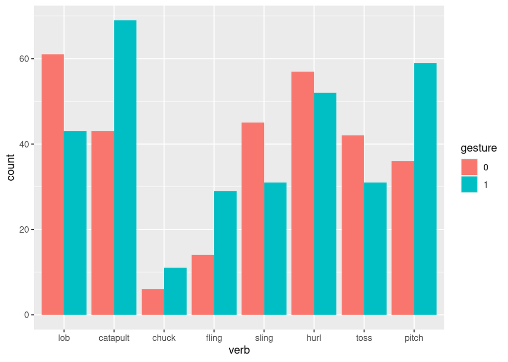

```r
gestures %>% ggplot(aes(x = verb, fill = gesture)) +
  geom_bar(position = position_dodge())
```

- mixed picture: some verbs do indeed seem to elicit more gestures than others
- fitting a model quasi-identical to fitting linear model
- call `glm()` (generalised linear model) instead of `lm()`
- ask for logistic regression via `family="binomial"`:

```r
model.verb <- glm(gesture ~ verb + 0,
                  family = "binomial", data = gestures)
summary(model.verb)
```

```
##
## Call:
## glm(formula = gesture ~ verb + 0, family = "binomial", data = gestures)
##
## Deviance Residuals:
##     Min       1Q   Median       3Q      Max
## -1.4981  -1.0515   0.8876   0.9843   1.3392
##
## Coefficients:
##              Estimate Std. Error z value Pr(>|z|)
## verblob      -0.34967    0.19912  -1.756   0.0791 .
## verbcatapult  0.47291    0.19429   2.434   0.0149 *
## verbchuck     0.60614    0.50752   1.194   0.2324
## verbfling     0.72824    0.32544   2.238   0.0252 *
## verbsling    -0.37268    0.23341  -1.597   0.1103
## verbhurl     -0.09181    0.19177  -0.479   0.6321
## verbtoss     -0.30368    0.23679  -1.283   0.1997
## verbpitch     0.49402    0.21149   2.336   0.0195 *
## ---
## Signif. codes:  0 '***' 0.001 '**' 0.01 '*' 0.05 '.' 0.1 ' ' 1
##
## (Dispersion parameter for binomial family taken to be 1)
##
##     Null deviance: 871.98  on 629  degrees of freedom
## Residual deviance: 845.81  on 621  degrees of freedom
## AIC: 861.81
##
## Number of Fisher Scoring iterations: 4
```

```r
# identical:
model.verb <- glm(gesture ~ verb + 0,
                  family = binomial(link = logit), data = gestures)

summary(model.verb)
```

```
##
## Call:
## glm(formula = gesture ~ verb + 0, family = binomial(link = logit),
##     data = gestures)
##
## Deviance Residuals:
##     Min       1Q   Median       3Q      Max
## -1.4981  -1.0515   0.8876   0.9843   1.3392
##
## Coefficients:
##              Estimate Std. Error z value Pr(>|z|)
## verblob      -0.34967    0.19912  -1.756   0.0791 .
## verbcatapult  0.47291    0.19429   2.434   0.0149 *
## verbchuck     0.60614    0.50752   1.194   0.2324
## verbfling     0.72824    0.32544   2.238   0.0252 *
## verbsling    -0.37268    0.23341  -1.597   0.1103
## verbhurl     -0.09181    0.19177  -0.479   0.6321
## verbtoss     -0.30368    0.23679  -1.283   0.1997
## verbpitch     0.49402    0.21149   2.336   0.0195 *
## ---
## Signif. codes:  0 '***' 0.001 '**' 0.01 '*' 0.05 '.' 0.1 ' ' 1
##
## (Dispersion parameter for binomial family taken to be 1)
##
##     Null deviance: 871.98  on 629  degrees of freedom
## Residual deviance: 845.81  on 621  degrees of freedom
## AIC: 861.81
##
## Number of Fisher Scoring iterations: 4
```

- NB: we do not fit an intercept (we do this by adding “+ 0” to the formula, see above), so that intercepts for each category are easily interpretable
- some significance for some verbs

#### metaphorical use

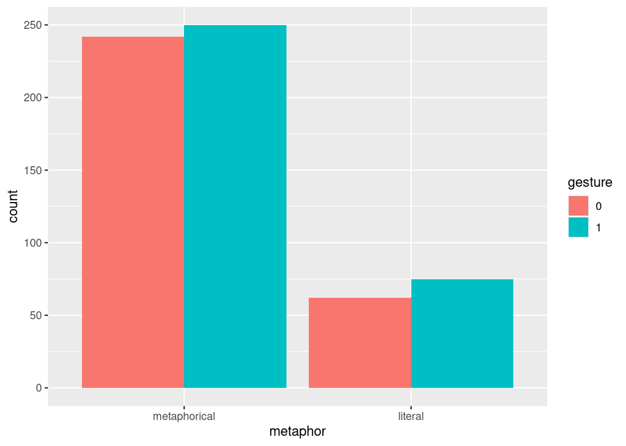

```r
gestures %>% ggplot(aes(x = metaphor, fill = gesture)) +
  geom_bar(position = position_dodge())
```

- metaphorical vs. literal doesn’t seem to explain much

```r
model.metaphor <- glm(gesture ~ metaphor + 0,
                      family = "binomial", data = gestures)
```

```r
summary(model.metaphor)
```

```
##
## Call:
## glm(formula = gesture ~ metaphor + 0, family = "binomial", data = gestures)
##
## Deviance Residuals:
##    Min      1Q  Median      3Q     Max
## -1.259  -1.191   1.098   1.164   1.164
##
## Coefficients:
##                      Estimate Std. Error z value Pr(>|z|)
## metaphormetaphorical  0.03252    0.09018   0.361    0.718
## metaphorliteral       0.19035    0.17165   1.109    0.267
##
## (Dispersion parameter for binomial family taken to be 1)
##
##     Null deviance: 871.98  on 629  degrees of freedom
## Residual deviance: 870.61  on 627  degrees of freedom
## AIC: 874.61
##
## Number of Fisher Scoring iterations: 3
```

- not significant

#### formality of situation

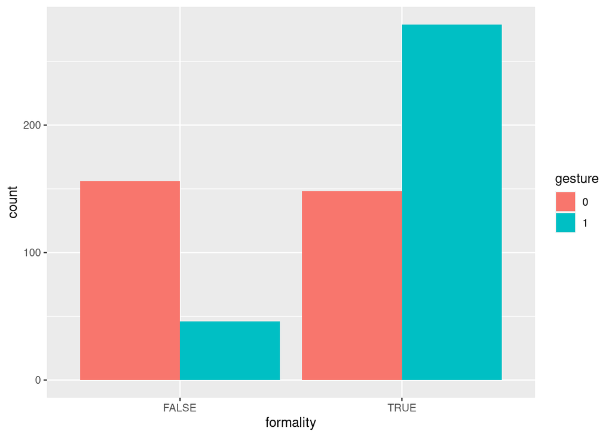

```r
gestures %>% ggplot(aes(x = formality, fill = gesture)) +
  geom_bar(position = position_dodge())
```

- formal situations seem to elicit more gestures!

```r
model.formality <- glm(gesture ~ formality + 0,
                       family = "binomial", data = gestures)

summary(model.formality)
```

```
##
## Call:
## glm(formula = gesture ~ formality + 0, family = "binomial", data = gestures)
##
## Deviance Residuals:
##     Min       1Q   Median       3Q      Max
## -1.4557  -0.7189   0.9226   0.9226   1.7203
##
## Coefficients:
##                Estimate Std. Error z value Pr(>|z|)
## formalityFALSE  -1.2212     0.1678  -7.279 3.37e-13 ***
## formalityTRUE    0.6340     0.1017   6.235 4.53e-10 ***
## ---
## Signif. codes:  0 '***' 0.001 '**' 0.01 '*' 0.05 '.' 0.1 ' ' 1
##
## (Dispersion parameter for binomial family taken to be 1)
##
##     Null deviance: 871.98  on 629  degrees of freedom
## Residual deviance: 767.85  on 627  degrees of freedom
## AIC: 771.85
##
## Number of Fisher Scoring iterations: 4
```

- significant intercepts

#### agitation

- now: metric predictor

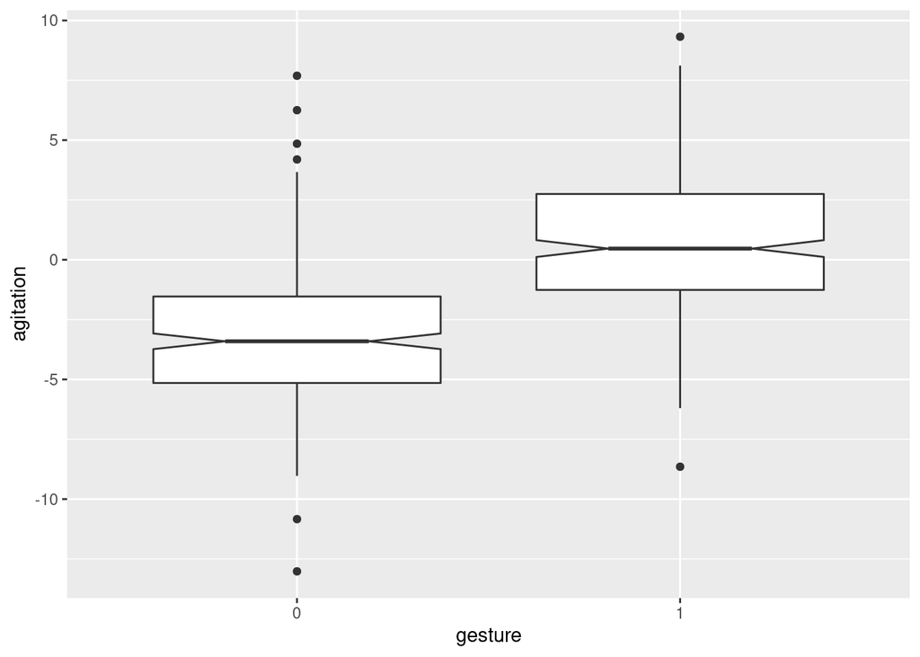

```r
gestures %>% ggplot(aes(x = gesture, y = agitation)) +
  geom_boxplot(notch = T)
```

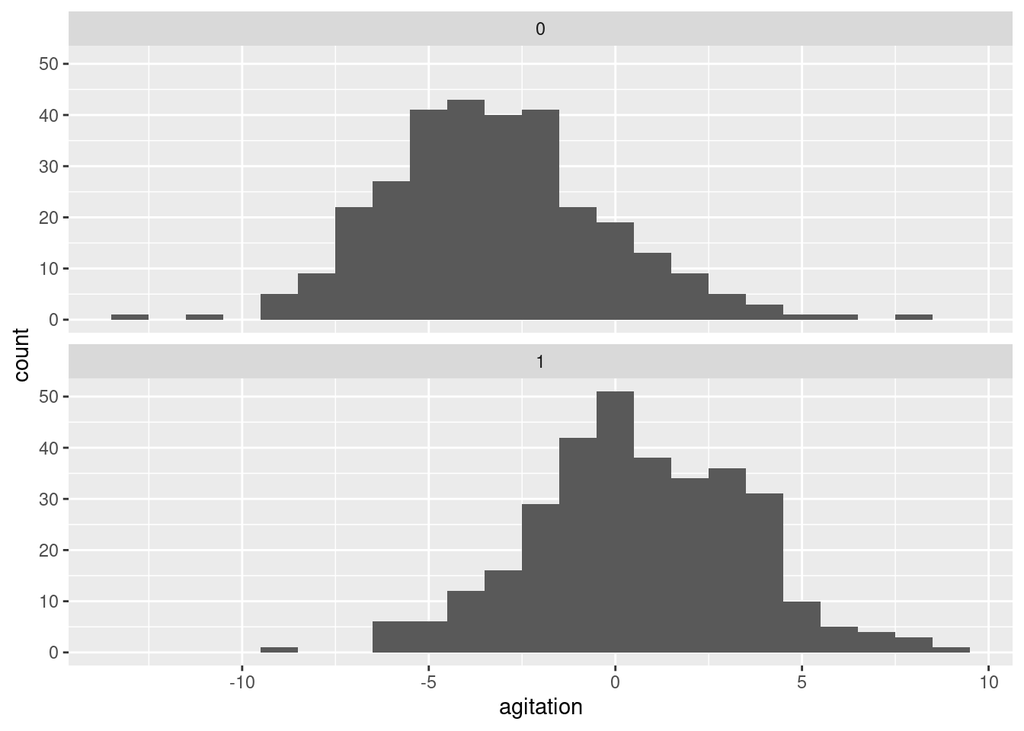

```r
gestures %>% ggplot(aes(x = agitation)) +
  geom_histogram(binwidth = 1) +
  facet_wrap(~ gesture, ncol = 1)
```

- looks like people produce more gestures when the conversation scores higher on the agitation measure (you don’t say!)

```r
model.agitation <- glm(gesture ~ agitation,
                       family = "binomial", data = gestures)

summary(model.agitation)
```

```
##
## Call:
## glm(formula = gesture ~ agitation, family = "binomial", data = gestures)
##
## Deviance Residuals:
##     Min       1Q   Median       3Q      Max
## -2.8716  -0.8113   0.2845   0.8501   2.5532
##
## Coefficients:
##             Estimate Std. Error z value Pr(>|z|)
## (Intercept)  0.65827    0.10974   5.999 1.99e-09 ***
## agitation    0.44840    0.03769  11.897  < 2e-16 ***
## ---
## Signif. codes:  0 '***' 0.001 '**' 0.01 '*' 0.05 '.' 0.1 ' ' 1
##
## (Dispersion parameter for binomial family taken to be 1)
##
##     Null deviance: 871.28  on 628  degrees of freedom
## Residual deviance: 645.44  on 627  degrees of freedom
## AIC: 649.44
##
## Number of Fisher Scoring iterations: 4
```

- significant intercepts
- visualisation:

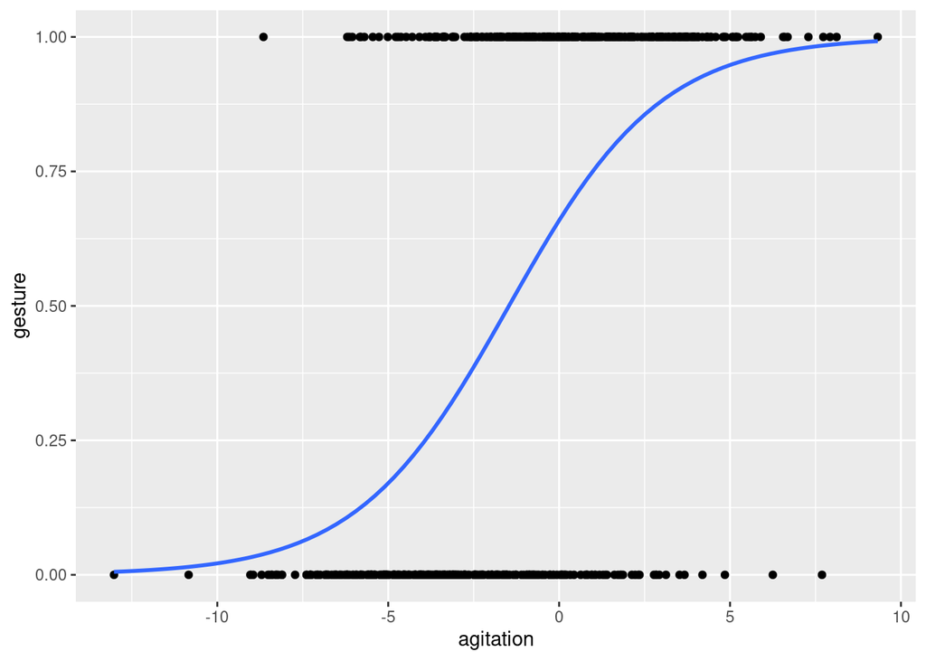

```r
gestures %>%
  mutate(gesture = (gesture == 1) + 0) %>%
  ggplot(aes(x = agitation, y = gesture)) +
  geom_point() +
  geom_smooth(method = glm, se = FALSE, method.args = list(family = binomial))
```

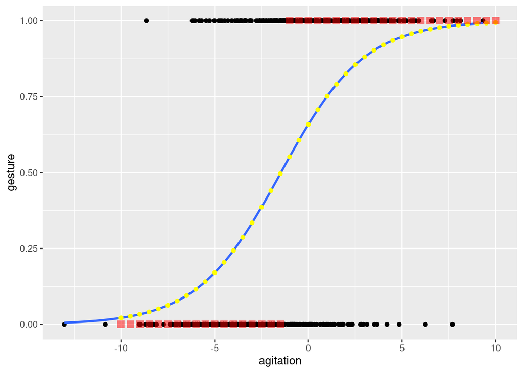

```r
explanatory_data <- expand_grid(
  agitation = seq(-10, 10, .5)
)
predicted_data <- explanatory_data %>% mutate(
  predict_odds = predict(model.agitation, explanatory_data),  # odds-ratio
  predict_prob = predict(model.agitation, explanatory_data, type = 'response'),  # probability
  predict_most = round(predict_prob) # most likely
)
gestures %>%
  mutate(gesture = (gesture == 1) + 0) %>%
  ggplot(aes(x = agitation, y = gesture)) +
  geom_point() +
  geom_smooth(method = glm, se = FALSE, method.args = list(family = binomial)) +
  geom_point(aes(x = agitation, y = predict_prob), color = 'yellow', data = predicted_data) +
    geom_point(aes(x = agitation, y = predict_most),
               color = 'red', shape = 15, size = 3, alpha = .5,
               data = predicted_data)
```

### multiple logistic regression

- function call works identically to multiple linear regression:

```r
model <- glm(gesture ~ verb + formality + agitation + metaphor + 0,
             family = "binomial", data = gestures)
summary(model)
```

```
##
## Call:
## glm(formula = gesture ~ verb + formality + agitation + metaphor +
##     0, family = "binomial", data = gestures)
##
## Deviance Residuals:
##     Min       1Q   Median       3Q      Max
## -3.2664  -0.6442   0.1874   0.6730   2.6170
##
## Coefficients:
##                 Estimate Std. Error z value Pr(>|z|)
## verblob         -1.13746    0.33049  -3.442 0.000578 ***
## verbcatapult    -0.17056    0.31002  -0.550 0.582215
## verbchuck       -0.48957    0.69529  -0.704 0.481355
## verbfling       -0.20858    0.49082  -0.425 0.670866
## verbsling       -0.80952    0.34336  -2.358 0.018392 *
## verbhurl        -1.29558    0.32261  -4.016 5.92e-05 ***
## verbtoss        -0.95889    0.36704  -2.613 0.008987 **
## verbpitch       -0.07949    0.32003  -0.248 0.803827
## formalityTRUE    1.92601    0.24490   7.865 3.71e-15 ***
## agitation        0.45296    0.04146  10.926  < 2e-16 ***
## metaphorliteral  0.14752    0.27737   0.532 0.594822
## ---
## Signif. codes:  0 '***' 0.001 '**' 0.01 '*' 0.05 '.' 0.1 ' ' 1
##
## (Dispersion parameter for binomial family taken to be 1)
##
##     Null deviance: 871.98  on 629  degrees of freedom
## Residual deviance: 553.22  on 618  degrees of freedom
## AIC: 575.22
##
## Number of Fisher Scoring iterations: 5
```

#### significance of variables

- for each row: does the variable explain something that hasn’t been explained by the ones before?
- here: likelihood-ratio test

```r
anova(model, test = "LRT")
```

```
## Analysis of Deviance Table
##
## Model: binomial, link: logit
##
## Response: gesture
##
## Terms added sequentially (first to last)
##
##
##           Df Deviance Resid. Df Resid. Dev  Pr(>Chi)
## NULL                        629     871.98
## verb       8   26.170       621     845.81 0.0009821 ***
## formality  1  105.346       620     740.46 < 2.2e-16 ***
## agitation  1  186.963       619     553.50 < 2.2e-16 ***
## metaphor   1    0.283       618     553.22 0.5947254
## ---
## Signif. codes:  0 '***' 0.001 '**' 0.01 '*' 0.05 '.' 0.1 ' ' 1
```

- NB: order important:

```r
model2 <- glm(gesture ~ formality + agitation + metaphor +verb + 0,
              family = "binomial", data = gestures)
anova(model2, test = "LRT")
```

```
## Analysis of Deviance Table
##
## Model: binomial, link: logit
##
## Response: gesture
##
## Terms added sequentially (first to last)
##
##
##           Df Deviance Resid. Df Resid. Dev  Pr(>Chi)
## NULL                        629     871.98
## formality  2  104.127       627     767.85 < 2.2e-16 ***
## agitation  1  193.893       626     573.96 < 2.2e-16 ***
## metaphor   1    0.315       625     573.65  0.574862
## verb       7   20.428       618     553.22  0.004716 **
## ---
## Signif. codes:  0 '***' 0.001 '**' 0.01 '*' 0.05 '.' 0.1 ' ' 1
```

- extra NB: you can also use `anova()` to explicitly test different models against one another:

```r
anova(model.verb, model.metaphor, test = 'LRT')
```

```
## Analysis of Deviance Table
##
## Model 1: gesture ~ verb + 0
## Model 2: gesture ~ metaphor + 0
##   Resid. Df Resid. Dev Df Deviance  Pr(>Chi)
## 1       621     845.81
## 2       627     870.61 -6  -24.805 0.0003711 ***
## ---
## Signif. codes:  0 '***' 0.001 '**' 0.01 '*' 0.05 '.' 0.1 ' ' 1
```

#### prediction

```r
explanatory_data <- expand_grid(
  verb = c("hurl", "catapult"),
  metaphor = factor(c('metaphorical', 'literal')),
  agitation = seq(-10, 10, .5),
  formality = c(T, F)
)
predicted_data <- explanatory_data %>% mutate(
  predict_odds = predict(model, explanatory_data),  # odds-ratio
  predict_prob = predict(model, explanatory_data, type = 'response')  # probability
)
```

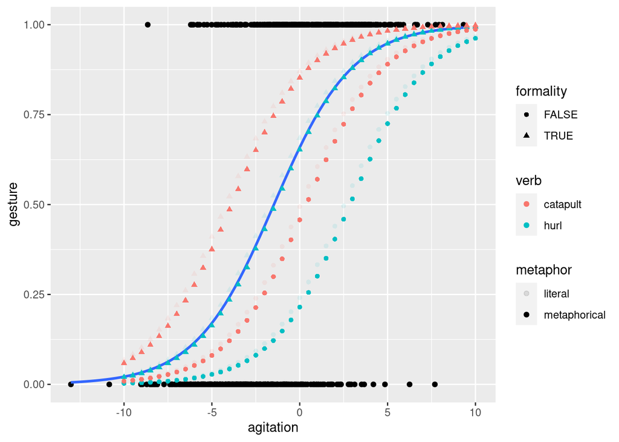

```r
gestures %>%
  mutate(gesture = (gesture == 1) + 0) %>%
  ggplot(aes(x = agitation, y = gesture)) +
  geom_point() +
  geom_smooth(formula = y ~ x, method = glm, se = FALSE, method.args = list(family = binomial)) +
  geom_point(aes(y = predict_prob,
                 x = agitation,
                 color = verb, shape = formality, alpha = metaphor),
             data = predicted_data)
```

#### goodness of fit

- accuracy: look at table

```r
gestures.fitted <- gestures %>% mutate(
  fitted = model$fitted.values,
  predicted = round(fitted)
)
mean(gestures.fitted$gesture == gestures.fitted$predicted)
```

```
## [1] 0.8012719
```

- best to use library yardstick for sensitivity (recall), specificity, precision

```r
model.eval <- yardstick::conf_mat(table(gestures.fitted$gesture, gestures.fitted$predicted))
summary(model.eval, event_level = 'first')
```

```
## # A tibble: 13 × 3
##    .metric              .estimator .estimate
##    <chr>                <chr>          <dbl>
##  1 accuracy             binary         0.801
##  2 kap                  binary         0.602
##  3 sens                 binary         0.803
##  4 spec                 binary         0.799
##  5 ppv                  binary         0.780
##  6 npv                  binary         0.822
##  7 mcc                  binary         0.602
##  8 j_index              binary         0.603
##  9 bal_accuracy         binary         0.801
## 10 detection_prevalence binary         0.483
## 11 precision            binary         0.780
## 12 recall               binary         0.803
## 13 f_meas               binary         0.791
```

```r
summary(model.eval, event_level = 'second')
```

```
## # A tibble: 13 × 3
##    .metric              .estimator .estimate
##    <chr>                <chr>          <dbl>
##  1 accuracy             binary         0.801
##  2 kap                  binary         0.602
##  3 sens                 binary         0.799
##  4 spec                 binary         0.803
##  5 ppv                  binary         0.822
##  6 npv                  binary         0.780
##  7 mcc                  binary         0.602
##  8 j_index              binary         0.603
##  9 bal_accuracy         binary         0.801
## 10 detection_prevalence binary         0.517
## 11 precision            binary         0.822
## 12 recall               binary         0.799
## 13 f_meas               binary         0.810
```